# SCopeLoomR Tutorial - Creating and reading .loom files

*HTML built on Feb 07, 2019 with SCopeLoomR **version 0.3.5***.

# Introduction

The .loom file format is designed to store very large omics datasets. It has been created is maintained by the [Linnarsson lab](http://linnarssonlab.org/), and its naming conventions are described in [loompy](http://linnarssonlab.org/loompy/conventions/index.html)

`SCopeLoomR` is an R package to easily create and manipulate .loom files. These loom files are compatible with [SCope](http://scope.aertslab.org), a loom viewer which also allows to visualize the results from [SCENIC](http://scenic.aertslab.org) (e.g.: regulon, regulon activities).

# Installation

For example:

```r
#install.packages("devtools")
devtools::install_github("aertslab/SCopeLoomR")
```

# Creating a loom object

## Load Data

Load the data to include in the loom file:

```r
library(SingleCellExperiment)
library(SCopeLoomR)
data(sce) # e.g. a SingleCellExperiment

# DGEM (Digital gene expression matrix)
dgem <- counts(sce)
  dim(dgem)
```

```
## [1]  50 100
```

```r
  class(dgem)
```

```
## [1] "matrix"
```

```r
  head(colnames(dgem))  #should contain the Cell ID/name
```

```
## [1] "cell_1" "cell_2" "cell_3" "cell_4" "cell_5" "cell_6"
```

```r
# Known cell information/annotation
cell.info <- colData(sce)
cell.info$nGene <- colSums(dgem>0)
  head(cell.info)
```

```
## DataFrame with 6 rows and 2 columns
##           cellType     nGene
##        <character> <numeric>
## cell_1      type_3        15
## cell_2      type_6        13
## cell_3      type_5         2
## cell_4      type_7        10
## cell_5      type_5         5
## cell_6      type_7        14
```

```r
# Default embedding (e.g. t-SNE or PCA coordinates)
data(tSNE_expr)
default.tsne <- tSNE_expr
default.tne.name <- "t-SNE on full expression matrix"
head(default.tsne)
```

```
##             tsne1       tsne2
## cell_1  -7.624841 -38.3060376
## cell_2 -10.565992 -34.6841492
## cell_3  -1.873907  34.6971310
## cell_4  -5.917156 -15.6232567
## cell_5   1.731850  32.7509413
## cell_6  -3.253512   0.1512039
```

## Create loom file

Minimum information required to create the .loom object:

```r
library(SCopeLoomR)

### Create the minimal loom file
file.name <- "example.loom"
loom <- build_loom(file.name=file.name,
                   dgem=dgem,
                   title="Fake expression dataset for examples",
                   genome="Mouse", # Just for user information, not used internally
                   default.embedding=default.tsne,
                   default.embedding.name=default.tne.name)
```

```
## [1] "Adding global attributes..."
## [1] "Adding matrix..."
##
## [1] "Adding default metrics nUMI..."
## [1] "Adding default metrics nGene..."
## [1] "Adding default embedding..."
## [1] "Adding row attributes..."
## [1] "Adding columns edges..."
## [1] "Adding row edges..."
## [1] "Adding layers..."
```

## Add optional information

### Hierarchy

You can organize/group your .loom files in SCope by specifiying differents grouping levels. The current .loom file will be put in `Mouse -> Toy Datasets` branch of the SCope loom tree.

```r
add_hierarchy(loom = loom, hierarchy = create_hierarchy(level.1.name = "Mouse", level.2.name = "Toy Datasets", level.3.name = ""))
```

The same command can be used to update the hierarchy of a .loom file (set `overwrite=TRUE`):

```r
add_hierarchy(loom = loom, hierarchy = create_hierarchy(level.1.name = "[level-1-name]", level.2.name = "[level-2-name]", level.3.name = "[level-3-name]"), overwrite = T)
```

### Annotations/metrics

Annotations and/or metrics can be added to query in [SCope](http://scope.aertslab.org).

```r
# Add annotation (categorical variable)
add_col_attr(loom=loom, key = "Cell type", value=cell.info$cellType, as.annotation=T)
# Add metric (numerical variable)
add_col_attr(loom=loom, key = "Age", value=sample(0:20, nrow(cell.info), replace=T), as.metric = T)
```

### SCENIC results

```r
scenic.dir <- file.path(system.file('extdata', package='SCopeLoomR'), "SCENIC_fakeOutput/") # Modify for your analysis

# Regulon activity (AUC matrix)
library(AUCell)
regulonsAUC <- readRDS(file.path(scenic.dir, "int/3.4_regulonAUC.Rds"))
add_scenic_regulons_auc_matrix(loom=loom, regulons.AUC=getAUC(regulonsAUC))

# Regulons (gene list), regulon thresholds (optional) and regulon motifs (optional)
regulons <- readRDS(file.path(scenic.dir, "int/3.1_regulons_forAUCell.Rds"))
aucThresholds <- readRDS(file.path(scenic.dir, "int/3.5_AUCellThresholds.Rds"))
regulon.enrichment.table <- NULL # readRDS(file.path(scenic.dir, "int/2.3_motifEnrichment.Rds"))
add_scenic_regulons(loom=loom
                    , regulons=regulons
                    , regulon.threshold.assignments=aucThresholds# $threshold.assignment # Optional
                    , regulon.enrichment.table = regulon.enrichment.table) # Optional

# Alternative t-SNE
tSNE <- readRDS(file.path(scenic.dir, "int/tSNE_AUC_50pcs_50perpl.Rds"))
add_embedding(loom=loom, embedding=tSNE$Y, name="SCENIC (t-SNE on AUC)")
```

```
## [1] "Adding embedding SCENIC (t-SNE on AUC)..."
```

### Seurat results

*(Not run in this example. You would need to use your own file names)*

```r
seurat.dir <- "Seurat_output/"
seurat.tsne <- readRDS(file = paste0(seurat.dir, "seurat_tsne.rds.gz"))
seurat <- readRDS(paste0(seurat.dir, "seuratObject.rds.gz"))

# Add extra embeddings
add_embedding(loom=loom, embedding=seurat.tsne, name="Seurat 82PC, 30perp"))
```

#### Clusterings

```r
add_seurat_clustering(loom = loom
                      , seurat = seurat)
```

##### Adding clustering(s) along with annotation for a given resolution (default one if set)

```r
seurat.annotation<-read.table(file = paste0(seuratDir, "Res2_Clusters.tsv", header=T, quote = '', sep = "\t", stringsAsFactors=F))
add_seurat_clustering(loom = loom
                      , seurat = seurat
                      , default.clustering.resolution = "res.2"
                      , annotation = seurat.annotation
                      , annotation.cluster.id.cn = "res.2"
                      , annotation.cluster.description.cn = "Annotation")
```

##### Adding clustering(s) along with cluster markers

```r
seurat.resolutions <- get_seurat_clustering_resolutions(seurat = seurat)
seurat.markers.file.path.list<-do.call(what = "c", lapply(X=seurat.resolutions, FUN=function(resolution) {
  l<-list()
  l[paste0("res.",resolution)]<-paste0(seuratDir, "res.",resolution,"/Seurat_PC82_res",resolution,"_bimod_Cluster_Markers.rds.gz")
  return (l)
}))
add_seurat_clustering(loom = loom
                      , seurat = seurat
                      , seurat.markers.file.path.list = seurat.markers.file.path.list)
```

##### Adding clustering(s), along with cluster markers and metrics (e.g.: logFC, p-value, …)

```r
add_seurat_clustering(loom = loom
                      , seurat = seurat
                      , seurat.markers.file.path.list = seurat.markers.file.path.list
                      , seurat.marker.metric.accessors = c("avg_logFC", "p_val_adj")
                      , seurat.marker.metric.names = c("Avg. logFC", "Adj. p-value")
                      , seurat.marker.metric.description = c("Average log fold change from Wilcox differential test (cfr. Seurat)"
                                                             , "Adjusted p-value using Bonferroni correction based on the total number of genes in the dataset (cfr. Seurat)"))
```

### Single-cell trajectories

**Monocle**: Adding the trajectory data from a CellDataSet object generated by monocle.

```r
# Add monocle embedding and trajectory
S_matrix <- reducedDimS(cds)
monocle.embedding<-data.frame(t(S_matrix[c(1, 2), ]))
add_embedding(loom = loom, embedding = monocle.embedding, name = "Monocle (DDRTree)", trajectory = create_trajectory_from_monocle(cds = cds))
```

## Finalize (save)

```r
finalize(loom=loom)
```

# Read data from a loom object

## Get the gene expression matrix

```r
loomPath <- file.path(system.file('extdata', package='SCopeLoomR'), "example.loom")
loom <- open_loom(loomPath, mode="r")
dgem <- get_dgem(loom)
close_loom(loom)
dgem[1:5,1:5]
```

```
##        cell_1 cell_2 cell_3 cell_4 cell_5
## gene_1      0      0      0      0      0
## gene_2      0      0      0      0      0
## gene_3      1      5      0      2      0
## gene_4      0      0      0      0      0
## gene_5      0      0      0      0      0
```

## Get the gene expression matrix of a given cluster

This .loom file can be downloaded at http://scope.aertslab.org in the left panel under `Drosophila` > `Brain`.

```r
loom <- open_loom(loom = "Aerts_Fly_AdultBrain_Filtered_57k.loom", mode="r")
cluster10_dgem <- get_cluster_dgem_by_name(loom = loom, cluster.name = "Astrocyte-like - Cluster 10")
close_loom(loom)
```

## Other general accessors

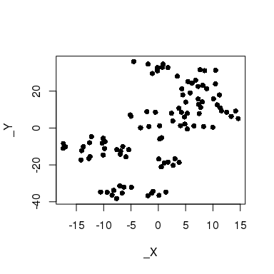

```r
loomPath <- file.path(system.file('extdata', package='SCopeLoomR'), "example.loom")
loom <- open_loom(loomPath, mode="r")

# SCENIC results:
regulons_incidMat <- get_regulons(loom)
regulonsAUC <- get_regulonsAuc(loom)
regulonsAucThresholds <- get_regulonThresholds(loom)
embeddings <- get_embeddings(loom)
close_loom(loom)

# Use the loaded info... e.g.:
plot(embeddings[[1]], pch=16)
```

Don’t forget…

```r
close_loom(loom)
# or finalize(loom)
```